# Lab 6

Tianhao Jiang

```python
%matplotlib inline
import numpy as np
import matplotlib
import matplotlib.pyplot as plt
import scipy
import statistics
import h5py
import warnings
import xarray as xr
from scipy import stats
from scipy.optimize import curve_fit

#this sets the size of the plot to something useful
plt.rcParams["figure.figsize"] = (20,15)
```

# Confidence intervals

For this week we will be using the real data you are working on, but more as a background for the main activity rather than in depth explorations. Don't worry, more in-depth exploration the next two weeks!

## Setup

First, we want to have some `background' data (presumably signal free) onto which we can inject a simulated signal. So the first step is to isolate some appropriate data from your data files.

LHC

**For the LHC data, we are going to have to fake a background. Make a Poisson background with mean 100.**

I made the background by drawing 1 million points from a Poisson with mean 100:

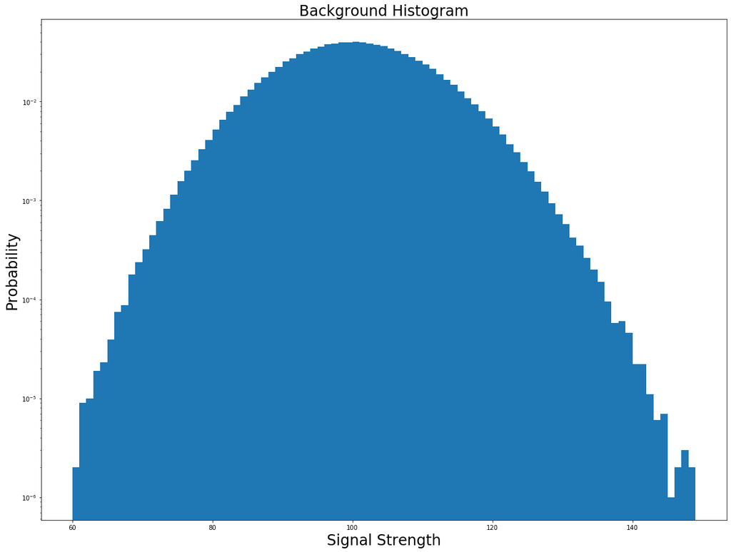

```python
data_size = 1000000
bkgd_mean = 100
bkgd = np.random.poisson(bkgd_mean,size=data_size)
#signal_size = 5
#signal = np.random.uniform(0,20,data_size)
plt.hist(bkgd,bins=range(60,150),density=True)
plt.title("Background Histogram",fontsize=24)
plt.xlabel("Signal Strength",fontsize=24)
plt.yscale("log")
plt.ylabel("Probability",fontsize=24)
plt.show()
```

## Problem 1

**The first problem is to look at your background distribution and determine where the 5σ sensitivity threshold is.**

```python
q = stats.norm.cdf(5);
threshold = stats.poisson.ppf(q,bkgd_mean)
print("The 5-sigmas threshold is at counts=%.2f" % threshold)
```

```
The 5-sigmas threshold is at counts=154.00
```

## Problem 2

**Now inject a signal of known strength. You will want to make your signal moderately strong, say somewhere in the 8-30σ range. Inject this signal into your background data many times.**

I chose to inject a signal of strength 300 1000 times.

Poissons with large means approach Gaussians. The background poisson has mean = 100 and standard deviation = 10

**a) Histogram how bright the observed signal appears to be, and discuss it's shape. Say in words what this histogram is telling you.**

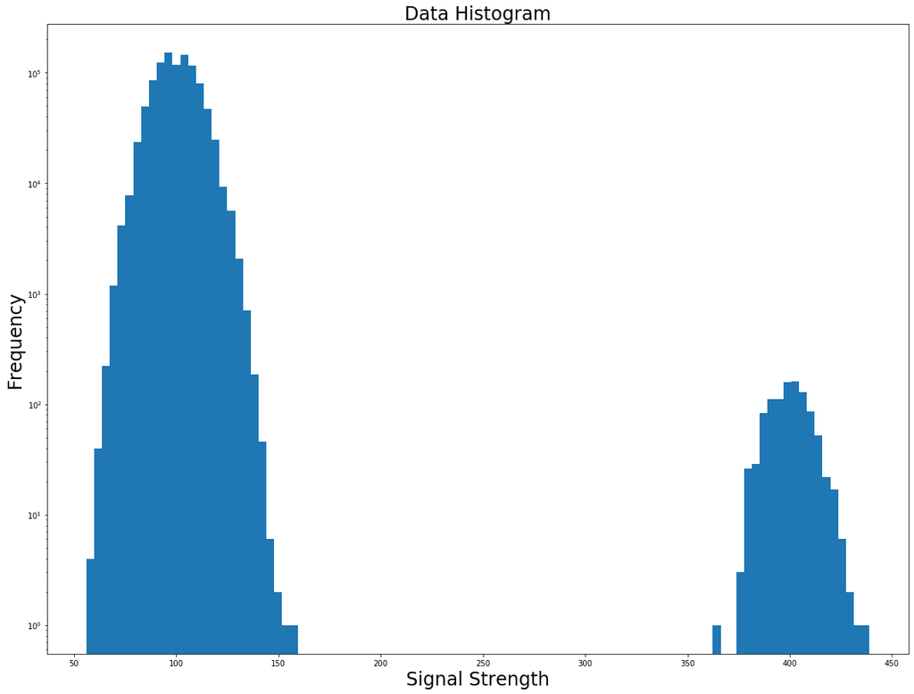

```python
signal_strength = 300
signal_count = 1000
signal = np.zeros(data_size)
signal[0:signal_count] = [signal_strength]*signal_count
data = bkgd+signal
plt.hist(data,bins=100)
plt.yscale("log")
plt.title("Data Histogram",fontsize=24)
plt.xlabel("Signal Strength",fontsize=24)
plt.ylabel("Frequency",fontsize=24)
plt.show()
```

The smaller peak on the right is the histogram of the observed signal. The ovserved signal appears to have a strength of 400, a shape of a Gaussian, and a width the same as that of the background. The histogram tells me the distribution of the observed data when the real data has a strength of 300.

**b) Is your observed signal biased? (e.g. is the observed value equally likely to be stronger or weaker than the true injected signal?) Is it symmetric?**

My observed signal is biased because the mean of its distribution is about larger than the true injected signal. The observed signal appears symmetric.

## Problem 3

**Now make a suite of injected signals. You will want to have a range of injected signal strengths, starting at zero and extending well above 5σ (30σ or more). You will want to follow the work you did for Homework 5 very closely.**

**a) Clearly state what you are simulating, and make a 2D histogram of injected signal vs. observed data**

I simulated the observe data by first simulation the real data by drawing 1 million points from a uniform distribution that ranges from 0 to 500 and then combining the real signal with the background.

I'm not sure if the data should be discrete or continuous. But since the backgroud is Poisson, I assume the data is discrete.

```python
signal2 = np.random.randint(0,500,data_size)

data2 = bkgd + signal2
```

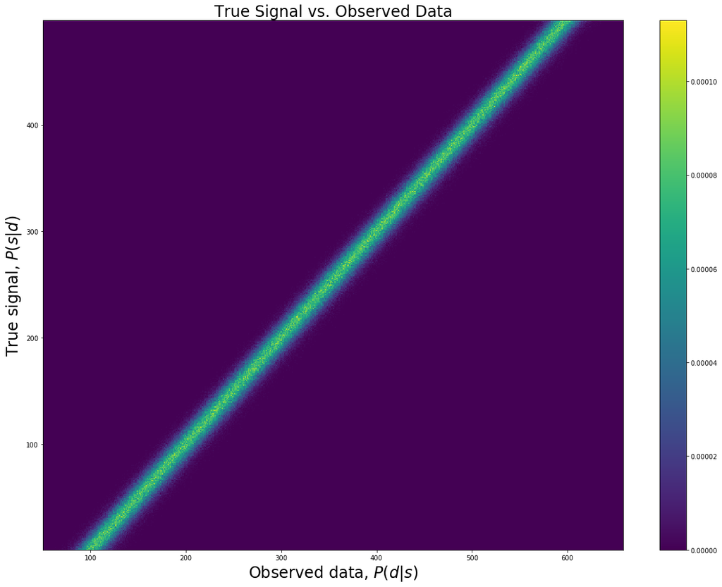

```python
signaledges = np.array(range(0,500))
dataedges = np.array(range(50,660))

fig, ax = plt.subplots()
Psd,xedges,yedges = np.histogram2d(data2,signal2, bins=[dataedges,signaledges], density=True)
datacenters = (dataedges[:-1] + dataedges[1:]) / 2
signalcenters = (signaledges[:-1] + signaledges[1:]) / 2
h1=ax.pcolormesh(datacenters,signalcenters,Psd.T)
fig.colorbar(h1,ax=ax)
ax.set_ylabel('True signal, $P(s|d)$', fontsize = 24)
ax.set_xlabel('Observed data, $P(d|s)$', fontsize = 24)
ax.set_title('True Signal vs. Observed Data', fontsize = 24)
plt.show()
```

**b) For the same injected signal power as in problem 2, show that you get the same answer.**

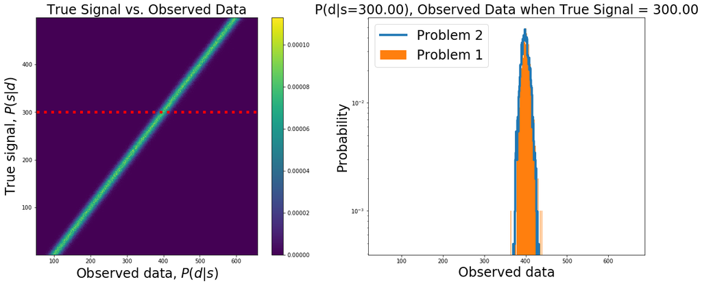

```python
fig, ax = plt.subplots(1, 2, figsize=(20,8))
Psd,xedges,yedges = np.histogram2d(data2,signal2, bins=[dataedges,signaledges], density=True)
datacenters = (dataedges[:-1] + dataedges[1:]) / 2
signalcenters = (signaledges[:-1] + signaledges[1:]) / 2
h1=ax[0].pcolormesh(datacenters,signalcenters,Psd.T)
fig.colorbar(h1,ax=ax[0])
ax[0].set_ylabel('True signal, $P(s|d)$', fontsize = 24)
ax[0].set_xlabel('Observed data, $P(d|s)$', fontsize = 24)
ax[0].set_title('True Signal vs. Observed Data', fontsize = 24)
y = 300
for index in range(0,len(yedges)):
    if yedges[index] >= y:
        break
y = yedges[index]
ax[0].plot([xedges[1],xedges[len(xedges)-2]],[y,y],'r:',linewidth=5)
observed_data = Psd[:,index] / sum(Psd[:,index]) # normalize the histogram
ax[1].step(xedges[0:len(xedges)-1],observed_data,linewidth=4,label="Problem 2")
ax[1].hist(data[0:signal_count],bins = range(300,500),density=True,label="Problem 1")
plt.legend(fontsize=24)
ax[1].set_yscale('log')
ax[1].set_ylabel('Probability', fontsize = 24)
ax[1].set_xlabel('Observed data', fontsize = 24)
ax[1].set_title('P(d|s=%.2f), Observed Data when True Signal = %.2f' % (y,y), fontsize = 24)
plt.show()
```

**c) Now reverse the problem, select an observed data value (pick something quite a bit stronger than 5σ) and create a 1D histogram of the true signal probability given the observed data. Describe the meaning of this histogram.**

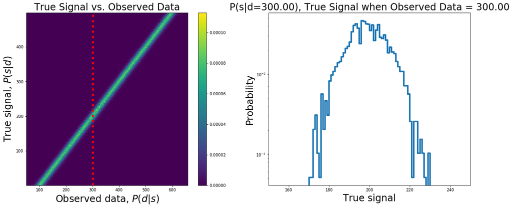

```python
fig, ax = plt.subplots(1, 2, figsize=(20,8))
Psd,xedges,yedges = np.histogram2d(data2,signal2, bins=[dataedges,signaledges], density=True)
datacenters = (dataedges[:-1] + dataedges[1:]) / 2
signalcenters = (signaledges[:-1] + signaledges[1:]) / 2
h1=ax[0].pcolormesh(datacenters,signalcenters,Psd.T)
fig.colorbar(h1,ax=ax[0])
ax[0].set_ylabel('True signal, $P(s|d)$', fontsize = 24)
ax[0].set_xlabel('Observed data, $P(d|s)$', fontsize = 24)
ax[0].set_title('True Signal vs. Observed Data', fontsize = 24)
x = 300
for index in range(0,len(xedges)):
    if xedges[index] >= x:
        break
x = xedges[index]
ax[0].plot([x,x],[yedges[1],yedges[len(yedges)-2]],'r:',linewidth=5)
true_signal = Psd[index,:] / sum(Psd[index,:]) # normalize the histogram
ax[1].step(yedges[0:len(yedges)-1],true_signal,linewidth=4)
ax[1].set_yscale('log')
ax[1].set_ylabel('Probability', fontsize = 24)
ax[1].set_xlim(150,250)
ax[1].set_xlabel('True signal', fontsize = 24)
ax[1].set_title('P(s|d=%.2f), True Signal when Observed Data = %.2f' % (y,y), fontsize = 24)
plt.show()
```

The resulting plot is on the right. The plot is a histogram of the (approximate) probability of the true signal strengths if I measure a signal to be 300.

This plot is a slice of the 2D histogram of True Signal vs Observed Data as shown by the red dashed line on the left.

**d) For your observed signal, what is the 1σ uncertainty on the true signal strength?**

```python
true_signal2=signal2[data2==300]
true_signal2.shape
q = stats.norm.cdf(-1) # Quanitile of -1-sigma
left = np.quantile(true_signal2,q)
right = np.quantile(true_signal2,1-q)
middle = np.quantile(true_signal2,0.5)
print("The signal is centered at %.1f" % middle)
print("The 1-sigma uncertainty of the true signal strength give nthe observed data = 300 is (%.1f,%.1f)" % (left,right))
```

```
The signal is centered at 199.0
The 1-sigma uncertainty of the true signal strength give nthe observed data = 300 is (190.0,209.0)
```

The uncertainty is 200 +/- 10

**e) Discuss the answer to part d in some depth. Is it symmetric? Is it biased? Does this make sense?**

The change of signal strength is the same when moving 1 sigma from the center of the distriubtion to its left or right. So the true signal strength distribution should be approximately symmetric. The true signal distribution is biased because the observed data is 300 while the true signal is centered at 200.

The result makes sense:

Signal + background = data. Also, the background is approximately symmetric and is centered at 100. So, when data = 300,

P(signal=x) = P(background=300-x) = P(background=100-(300-x-100)) = P(background=x-100),

which is symmetric and centered at 200.